Appendix C to the 2017 Georgia Milestones Growth Model Report:

Investigation of Potential Ceiling and Floor Effects.

Adam R. VanIwaarden

Damian W. Betebenner

National Center for the Improvement  
of Educational Assessment (NCIEA)

October 2017

DRAFT REPORT - DO NOT CITE!

# 1 Introduction

In the 2014-2015 academic year Georgia transitioned from its previous assessment program, the Criterion-Referenced Competency Tests (CRCT), to the [Georgia Milestones Assessment System.](http://www.gadoe.org/Curriculum-Instruction-and-Assessment/Assessment/Pages/Georgia-Milestones-Assessment-System.aspx) The transition included numerous changes to the assessment system including the incorporation of new performance standards. As other states have gone through similar assessment transitions, many have observed ceiling and floor effects in the new assessments (i.e. a relatively large proportion of students scoring at/near the scale extremes). These assessment ceilings/floors can telegraph onto the Student Growth Percentile (SGP) calculations.

With perfect data and model fit, the expectation is that the majority of SGPs for students scoring at or near the lowest obtainable scale score (LOSS) will be low (preferably less than 5 and not higher than 20), and that SGPs for students with the highest obtainable scale score (HOSS) will be high (higher than 95 and not less than 80). Ceiling effects in growth measures are somewhat more problematic than floor effects because students that consistently receive the highest scores are given lower than expected growth percentiles and are therefore negatively impacted. Conversely, the consistently lowest achieving students have higher estimated SGPs than expected. This could possibly conceal unacceptably low growth that might otherwise be identified and addressed.

In general these problems are caused by the way in which a “percentile” is most typically defined to begin with, and the inability of the assessments (and therefore the SGP model) to make granular distinctions between kids who score at the extremes of the test year after year. As an example, if a group of students were given a relatively easy test and 20% of them received a perfect score, these students would be defined as being in the 80<sup>th</sup> percentile of achievement because they scored higher than 80% of their peers. This is somewhat misleading however, because their score was *equal to* or greater than *all* of their peers and so could be also described as achieving at the 99<sup>th</sup> percentile under an equally valid definition.

To extend this heuristic from achievement to growth, if 50% of those top students also scored perfectly on the next test, we might estimate that they had 50<sup>th</sup> percentile growth. Although there is nothing *technically* incorrect about this estimate since their growth is fairly typical for their academic peer group, it is an inadequate or unsatisfactory assessment of their growth because they have consistently attained the highest levels. Furthermore, if it is typical for their peers to maintain perfect scores then even small deviations from a perfect score could produce *low growth* SGP estimates.

Typically only a few students are impacted by ceiling and floor effects, making them difficult to detect using traditional SGP diagnostic tools. The Center for Assessment has now added “Ceiling/Test Effects” indicators to the SGP model goodness of fit plots and is providing all clients even more rigorous diagnostic and descriptive analyses through this Appendix to the annual technical report. This report includes:

1. Scatter plots of the current and the most recent prior year’s test score distributions to indicate ceilings or floors in the data used in growth calculations.
2. Box plots showing the range and distribution of SGPs for *only* the highest and lowest achieving students in the current year.[^1]

# 2 Prior and Current Year Score Distributions

The marginal and conditional distributions of test scores can serve as a preliminary indicator of potential ceiling or floor effects in the calculation of student growth percentiles. Some minor problems could present themselves if these characteristics are present in either prior or current year scores, and are particularly likely when present in both.

The plots below depict distributions for the current year and the most recent prior year used in the SGP calculations for each content area and grade level. These plots start with a basic scatter plot of each student’s scores to show their conditional (joint) score distributions, and each point is depicted as the estimated SGP value based on their scores[^2]. On top of this is layered 1) **green contour lines** to provide a sense of the joint density, 2) three **non-linear magenta lines** identifying the bivariate relationship between prior and current scores at the 5<sup>th</sup>, 50<sup>th</sup> and 95<sup>th</sup> percentiles[^3], 3) **red** dotted lines that represent the cutoff for the highest and lowest 25+ current scale scores (corresponding with the first and last rows of the fit plot table), and 4) **rug plots** that depict the marginal distributions (prior scores shown in blue and current scores in red).

Ceiling or floor effects may be indicated by dark shaded SGP values in the extreme top-right or bottom-left corners of the plots. This suggests that staying at the extremes is common, which may lead to odd growth estimates for these high/low achieving students. We see very few issues in all content areas and grades in the 2016 and 2017 Georgia Milestones EOG data. Where minor ceilings appear in either years’ data, the opposite year score distributions for these students are well distributed, lessening the concern for a growth ceiling effect.

## 2.1 End-of-Grade Content Areas

**Fig. C.1:** Conditional distribution(s) of current and prior scale scores: ELA.

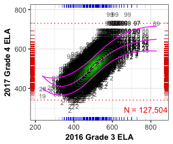

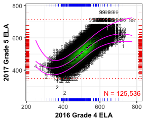

**Fig. C.2:** Conditional distribution(s) of current and prior scale scores: ELA *Continued*.

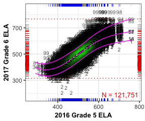

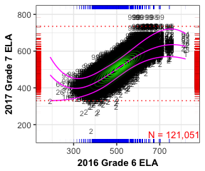

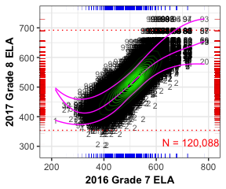

**Fig. C.3:** Conditional distribution(s) of current and prior scale scores: Mathematics.

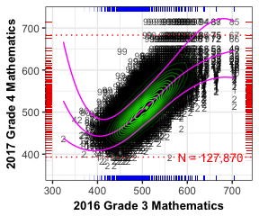

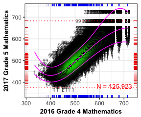

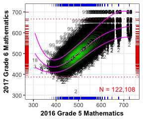

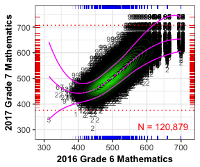

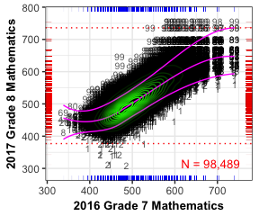

## 2.2 End-of-Course Test Subjects

The conditional density plots for the EOC test subjects are displayed below. The most recent prior is used in each plot to provide insight on the academic peer group based analyses. Some of these norm groups represent atypical student populations (e.g. course repeaters and skipped-year progressions), which can also cause ceiling effects for different reasons.

For example, the middle-right plot in Figure C.6 below for Algebra I course repeaters shows that the cohort is low achieving (as expected for students retaking the test) but there are seven students that attained the HOSS (785) in 2017. One also had a perfect score in 2016 and has an unexpectedly low SGP of 14 (data point in the upper-right hand corner). Another student of interest in this cohort scored the HOSS in 2016 and slightly lower in 2017, and has a SGP rank of 1. Both SGPs are probably an inaccurate assessments of the students’ growth since they have attained perfect or near perfect scores two years in a row. Given the sparsity of data points in the high achievement regions, the SGP model has struggled to produce appropriate growth estimates. Several other plots in other subjects also display a similar patterns.

**Fig. C.4:** Conditional distribution(s) of current and prior scale scores: 9<sup>th</sup> Grade Lit.

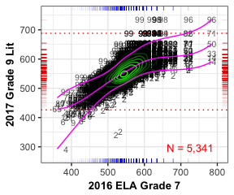

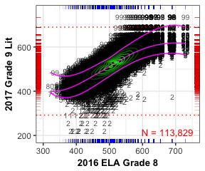

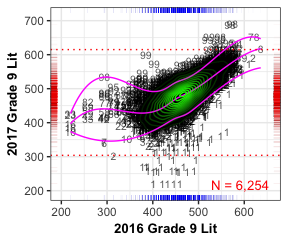

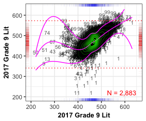

**Fig. C.5:** Conditional distribution(s) of current and prior scale scores: American Lit.

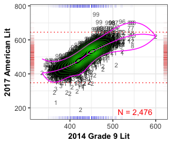

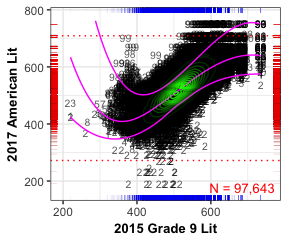

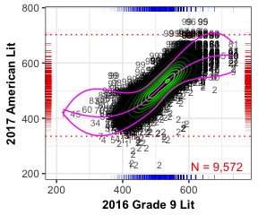

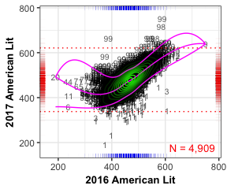

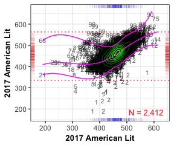

**Fig. C.6:** Conditional distribution(s) of current and prior scale scores: Algebra I.

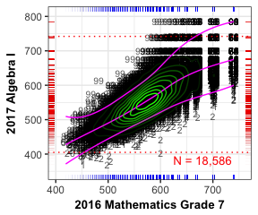

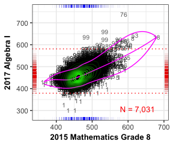

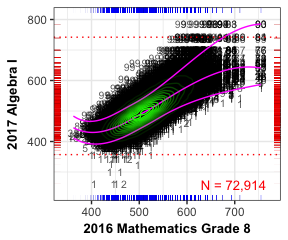